# DATA 308: Lab 6b

Inference with SLR

Author

Dylan Wikel

```r
library(ggfortify)
library(openintro)
library(broom)
library(tidyverse)
```

# Instructions

For this activity we will:

1. Specify a simple linear regression model to investigate the relationship of interest.
2. Specify our hypotheses.
3. Fit the proposed model.
4. Assess suitability of our proposed model.
5. Report our statistical decision, conclusion in context, and estimate of the association, indicating any model sensitivity.

# Investigation

## Research question

The [High School and Beyond Survey](https://nces.ed.gov/surveys/hsb/) is a survey conducted on high school seniors by the National Center of Education Statistics.

> Among high school seniors represented by the High School and Beyond survey, is there evidence of a linear association between standardized math and science scores?

Let’s consider standardized science scores to be our response variable.

## 1. Our model

State your proposed theoretical population model.

### Response

$\text{Standardized Science Score}_i = \beta_0 + \beta_1(\text{Standardized Math Score}) + \epsilon_i$

## 2. Hypotheses

State your hypotheses.

### Response

$H_0: \beta_1 = 0$ $H_a: \beta_1 \ne 0$

## Data

We will use the `hsb2` dataset from the `openintro` R package to investigate our research question. Start by entering `?hsb2` into the Console to bring up the help documentation, then run the code chunk below to glimpse your dataset.

```r
data("hsb2")

glimpse(hsb2)
```

```
Rows: 200
Columns: 11
$ id      <int> 70, 121, 86, 141, 172, 113, 50, 11, 84, 48, 75, 60, 95, 104, 3…
$ gender  <chr> "male", "female", "male", "male", "male", "male", "male", "mal…
$ race    <chr> "white", "white", "white", "white", "white", "white", "african…
$ ses     <fct> low, middle, high, high, middle, middle, middle, middle, middl…
$ schtyp  <fct> public, public, public, public, public, public, public, public…
$ prog    <fct> general, vocational, general, vocational, academic, academic, …
$ read    <int> 57, 68, 44, 63, 47, 44, 50, 34, 63, 57, 60, 57, 73, 54, 45, 42…
$ write   <int> 52, 59, 33, 44, 52, 52, 59, 46, 57, 55, 46, 65, 60, 63, 57, 49…
$ math    <int> 41, 53, 54, 47, 57, 51, 42, 45, 54, 52, 51, 51, 71, 57, 50, 43…
$ science <int> 47, 63, 58, 53, 53, 63, 53, 39, 58, 50, 53, 63, 61, 55, 31, 50…
$ socst   <int> 57, 61, 31, 56, 61, 61, 61, 36, 51, 51, 61, 61, 71, 46, 56, 56…
```

## 3. Fitting your model

Fit your proposed model.

### Response

```r
score_model <-
  lm(
  science ~ math,
  data = hsb2)

score_model
```

```
Call:
lm(formula = science ~ math, data = hsb2)

Coefficients:
(Intercept)         math
    16.7579       0.6666
```

## Viewing estimated model

Use `tidy()` to display the estimated coefficients, their standard errors, test statistics, p-values, and 95% confidence intervals. We have used `summary()` and `confint()` in the past, this is a different option that shows us all the results we want together.

### Response

```r
tidy(
  score_model,
  conf.int = TRUE
)
```

```
# A tibble: 2 × 7
  term        estimate std.error statistic  p.value conf.low conf.high
  <chr>          <dbl>     <dbl>     <dbl>    <dbl>    <dbl>     <dbl>
1 (Intercept)   16.8      3.12        5.38 2.11e- 7   10.6      22.9
2 math           0.667    0.0583     11.4  1.39e-23    0.552     0.782
```

## Estimate model

Write out the estimated regression equation.

### Response

$\hat{Y} = 16.75789 + 0.66658\times\text{Standardized Math Score}$

## 4. Assessing model suitability

We will assess each model condition and then investigate whether the fitted model is sensitive to unusual observations.

### 1. Independence

Are you concerned that the independence condition is not satisfied?

AKA: Based on the available information in the help documentation, is it reasonable to treat the observations as independent? Explain what evidence supports your assessment and identify any limitations in the available study information.

#### Response

I believe that the data should be indepedent as it is a random sample.

### Diagnostic plots

Generate the four standard diagnostic plots.

#### Response

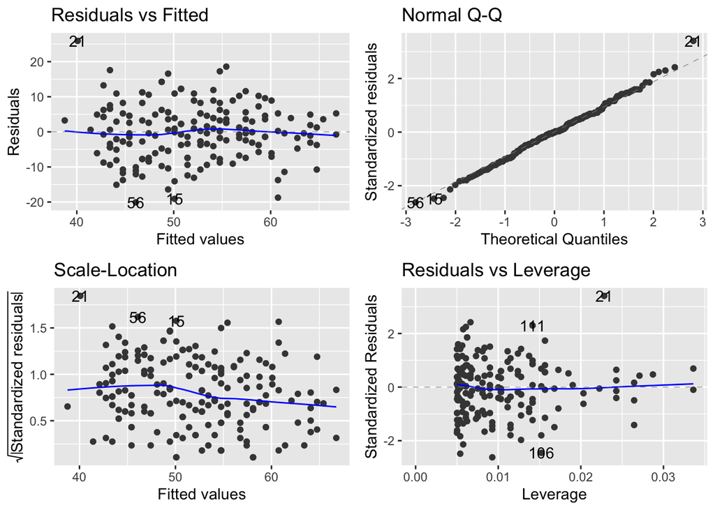

```r
autoplot(score_model)
```

### 2. Linearity

Are you concerned that the linearity condition is not satisfied?

#### Response

The linearity condition appears to be satisfied on visual inspection of the residuals vs. fitted plot as the data appear to follow a linear pattern around 0.

### 3. Constant variance

Are you concerned that the constant variance condition is not satisfied?

#### Response

The constant variance condition appears satisfied as the variance appears fairly constant in the residuals vs. fitted plot.

### 4. Normality

Are you concerned that the normality condition is not satisfied?

#### Response

When examining the Q-Q plot, the data appear to follow a fairly normal distribution. I believe that the normality condition is satisfied.

### Sensitivity to unusual observations

Use the residuals-versus-leverage plot to identify observations that may have relatively high influence. Are you concerned about any extreme observations? If so, use `slice()` to extract that observation.

*We will do this together.*

#### Response

```r
hsb2 |>
  slice(21)
```

```
# A tibble: 1 × 11
     id gender race  ses    schtyp prog     read write  math science socst
  <int> <chr>  <chr> <fct>  <fct>  <fct>   <int> <int> <int>   <int> <int>
1   167 male   white middle public general    63    49    35      66    41
```

```r
score_model_minus21 <- lm(science ~ math, data = slice(hsb2, -21))

tidy(score_model_minus21)
```

```
# A tibble: 2 × 5
  term        estimate std.error statistic  p.value
  <chr>          <dbl>     <dbl>     <dbl>    <dbl>
1 (Intercept)   15.2      3.06        4.97 1.47e- 6
2 math           0.693    0.0572     12.1  1.27e-25
```

I am not concerned about unusual values as I did not find concerning influential points.

## 5. Reporting your results

State your statistical decision with a significance level of 0.05.

### Response

Reject $H_0$ as we have a p-value of less than $0.05$ and less than $0.001$ where $p = 1.388621 \times 10^{-23}$

## Conclusion in context

State your conclusion in context. Recall:

- One sentence should be your conclusion for the hypothesis test, with the p-value provided in parentheses.
- The second sentence should be your estimate and 95% confidence interval interpreted in context.
- The third should mention if your results were especially sensitive to an extreme observation, and provide insight into that observation.

### Response

Our p-value $p = 1.388621 \times 10^{-23}$ is less than our significance value $p = 0.05$ so we can reject the null hypothesis. We expect an increase of 0.667 points in standarized science score for every unit increase in standardized math score, between 0.552 and 0.782 points higher with 95% confidence. While observing the data, no influential values were detected.

# Final reflection

Why does this study allow us to investigate an association but not establish that higher math scores cause higher science scores? Identify at least two variables or characteristics that might help explain the observed association.

### Response

The association between math and science scores should not be interpreted as a causal relationship because this was an observational study, and students were not randomly assigned different levels of math performance. Although higher math scores were associated with higher science scores, other factors may help explain this relationship. For example, students with stronger overall academic ability, greater access to educational resources, or more supportive learning environments may tend to perform well in both subjects. Because these factors were not experimentally controlled, we can conclude that math and science scores are associated, but not that higher math scores directly cause higher science scores.